# PSYC40940: Grammar of Graphics

## From Principles To Practice

- Week 2: Principles of data visualisation
- Week 3: Grammar of Graphics; aesthetics and attributes
- Week 4: Major visualisation tools
- Week 5: Customising visualisations (scales, themes, and labels)

## What You Should Take Away

By the end of the session, you should be able to:

- read a `ggplot2` plot as a set of layers
- explain the difference between aesthetics and attributes
- recognise when an aesthetic mapping helps or overloads a plot
- avoid overloaded mappings that make plots harder to read

Download the Week 3 files from NOW and move them into your RStudio Project folder.

There are two exercise files for today:

- `01_building_ggplot_layers.Rmd`
- `02_aesthetics_vs_attributes.Rmd`

## Building Plots With Grammar

## What Parts Make Up This Plot?

Before we name the grammar, identify what a plot is made from. What do you notice about the data, visual marks, colours, lines, labels, and layout?

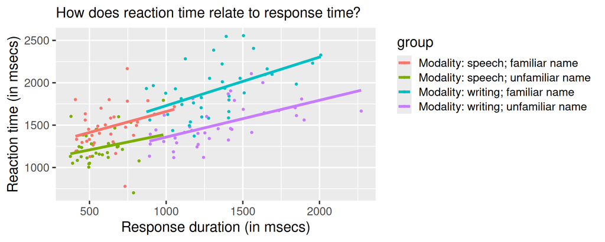

## Core Components

| Component | Example | Description |
| --- | --- | --- |
| **Data** | `d_spellname` | The dataset being plotted |
| **Aesthetics (aes)** | `x = dur, y = rt` | How data variables map to visual properties |
| **Geometries (geom)** | `geom_point()` | The type of plot element (points, bars, lines) |
| **Statistics (stat)** | `stat_smooth()` | Transformations of data (e.g., regression lines) |
| **Scales** | `scale_x_log10()` | How data values are converted to aesthetics |
| **Facets** | `facet_wrap(~group)` | Splitting data into small multiples |
| **Coordinate system** | `coord_polar()` | The space where data are drawn (Cartesian, polar) |
| **Theme** | `theme_minimal()` | Non-data display elements (fonts, text, grids, etc.) |

## Why `ggplot2` Uses A Grammar

- `ggplot2` is an R package for creating data visualisations.
- The “gg” stands for *Grammar of Graphics* (Wilkinson, 2005).
- A grammar means plots are built from reusable parts, rather than memorised as separate plot types.
- This helps you start simple and add complexity only when it helps the reader.
- See also Wickham (2016), Wickham (2010).

## What The Grammar Describes

A statistical graphic connects three main things:

- **data:** the variables we want to show
- **aesthetics:** how variables become visual properties such as position, colour, shape, or size
- **geometries:** the visible marks, such as points, lines, or bars

Other layers can then summarise, split, transform, label, or style the plot.

## Grammar As Building Blocks

Think about language: grammar tells us how words can be combined into sentences.

For plots, the grammar tells us how data, mappings, and visual marks can be combined.

The practical skill for today is to read a plot as layers: What data are used? What is mapped? What is drawn? What else has been added?

## The Three Required Parts

- **data:** the data you want to visualise indicated as `ggplot(data = ...)`
- **aesthetics:** mapping of data to graphic properties (axes, size, colour) indicated as `mapping = aes()`
- **geometries:** visual elements encoding the data indicated as `geom_...()`

## Required Parts: Data And Aesthetics

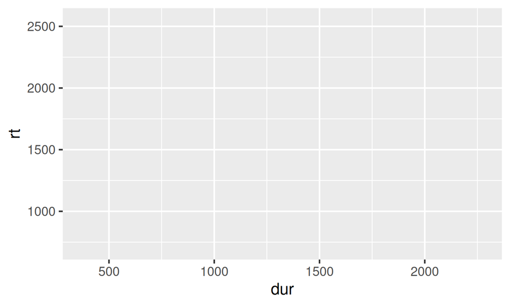

```r
ggplot(d_spellname, aes(x = dur, y = rt))
```

## Add A Geometry: Points

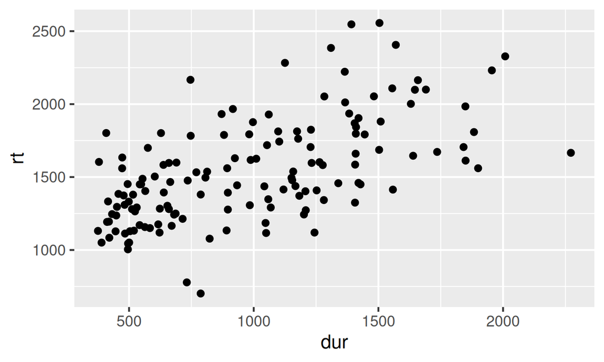

```r
ggplot(d_spellname, aes(x = dur, y = rt)) +
  geom_point()
```

## Add A Summary Layer: Trend Line

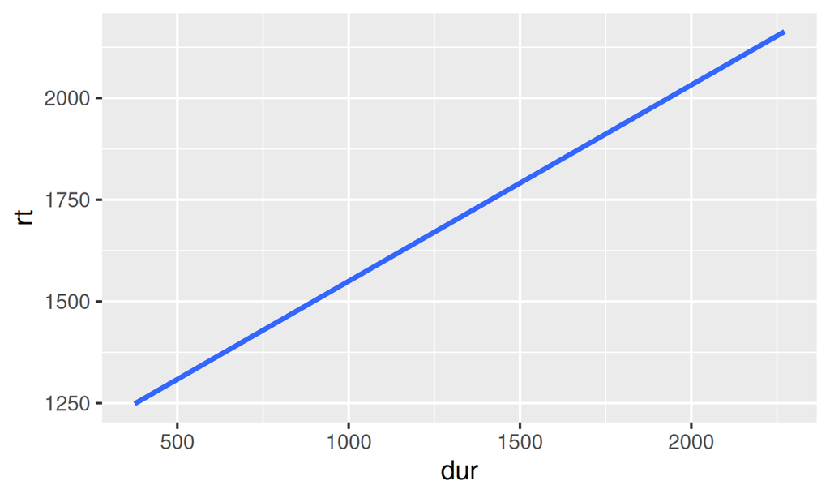

```r
ggplot(d_spellname, aes(x = dur, y = rt)) +
  stat_smooth(method = "lm", se = FALSE)
```

## Add A Geometry: Rug Marks

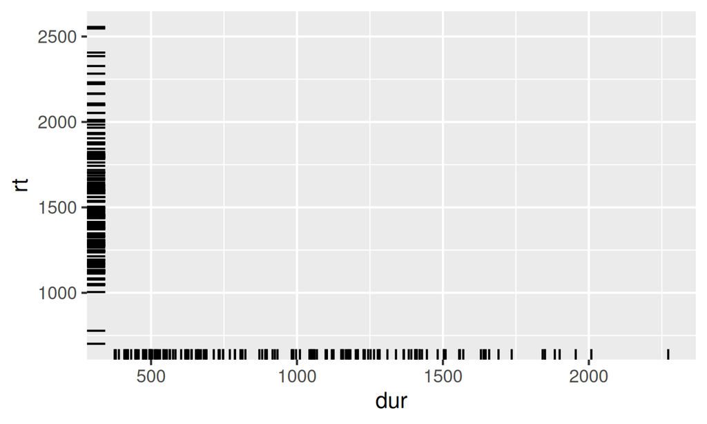

```r
ggplot(d_spellname, aes(x = dur, y = rt)) +
  geom_rug()
```

## Combine Multiple Layers

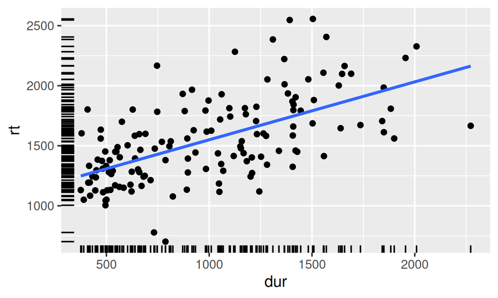

```r
ggplot(d_spellname, aes(x = dur, y = rt)) +
  geom_point() +
  stat_smooth(method = "lm", se = FALSE) +
  geom_rug()
```

## Layers You Can Add Later

- **facets:** dividing data into subplots
- **statistics:** statistical summaries
- **coordinates:** how the plotting space is arranged
- **theme:** visual properties not related to the data (font, background)

## Start With Data, Aesthetics, And Geometry

- data
- aesthetics
- geometries

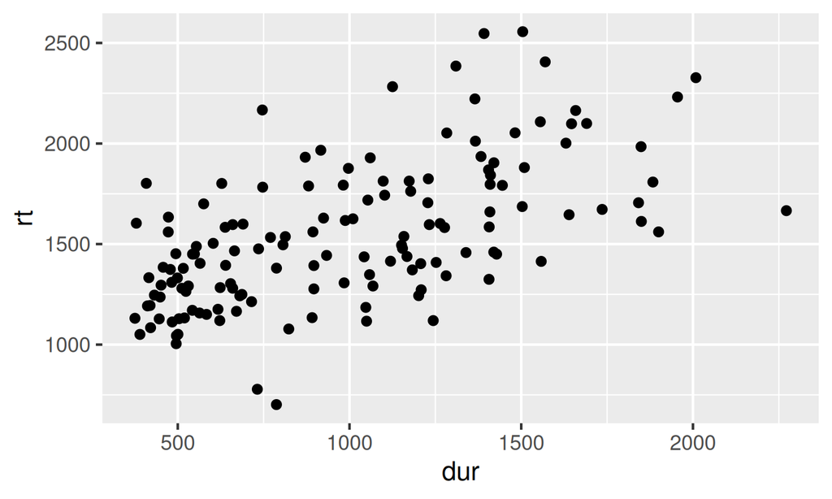

```r
ggplot(d_spellname, aes(x = dur, y = rt)) +
  geom_point()
```

## Add Facets To Split The Plot

- data
- aesthetics
- geometries
- facets

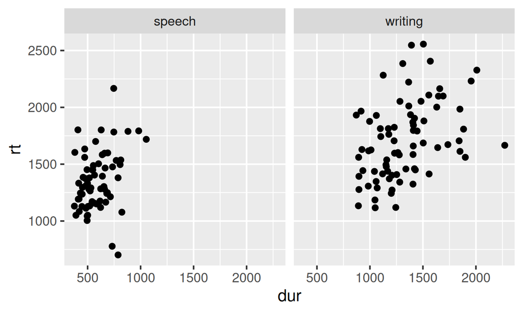

```r
ggplot(d_spellname, aes(x = dur, y = rt)) +
  geom_point() +
  facet_grid( ~ modality)
```

## Add A Statistical Summary

- data
- aesthetics
- geometries
- facets
- statistics

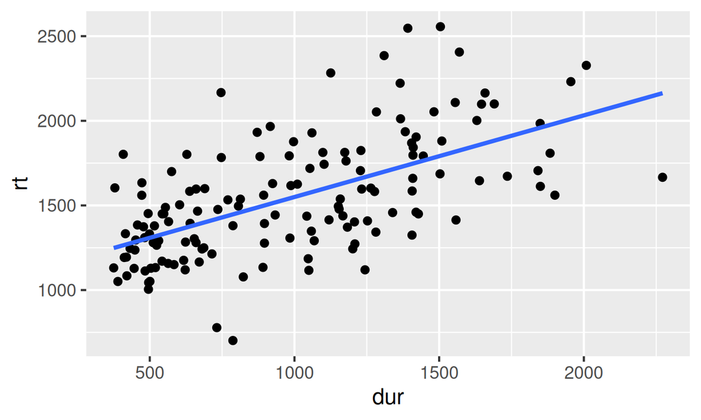

```r
ggplot(d_spellname, aes(x = dur, y = rt)) +
  geom_point() +
  stat_smooth(method = "lm", se = FALSE)
```

## Change The Coordinate System

- data
- aesthetics
- geometries
- facets
- statistics
- coordinates

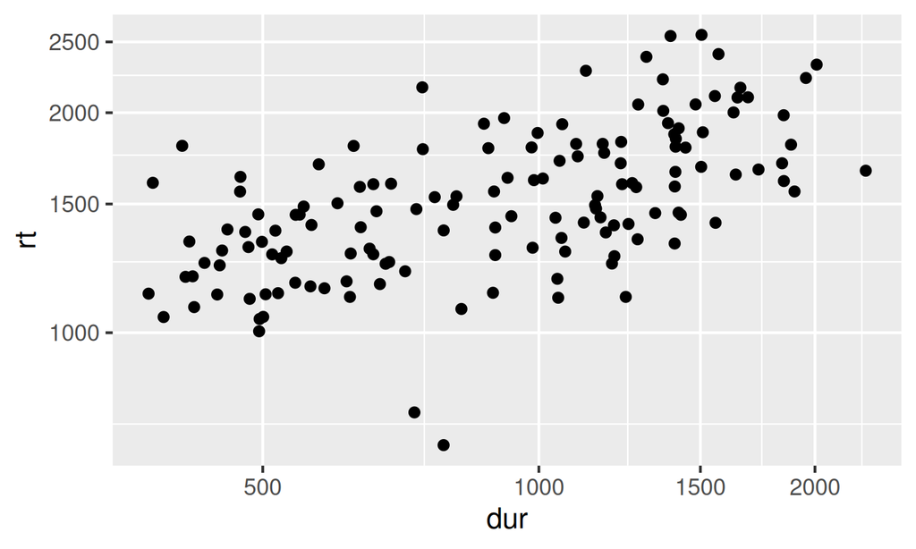

```r
ggplot(d_spellname, aes(x = dur, y = rt)) +
  geom_point() +
  coord_trans(x = "log", y = "log")
```

## Flip The Coordinates

- data
- aesthetics
- geometries
- facets
- statistics
- coordinates

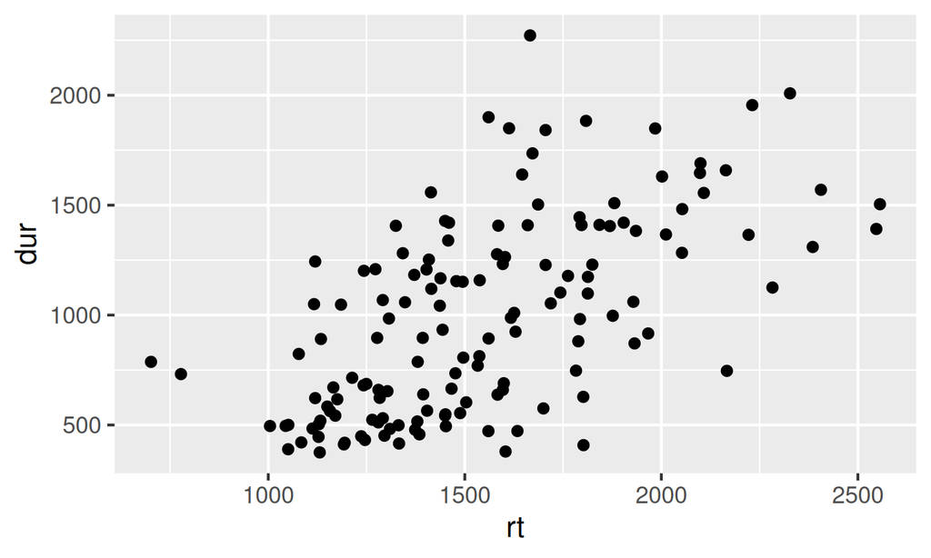

```r
ggplot(d_spellname, aes(x = dur, y = rt)) +
  geom_point() +
  coord_flip()
```

## Add A Theme

- data
- aesthetics
- geometries
- facets
- statistics
- coordinates
- theme

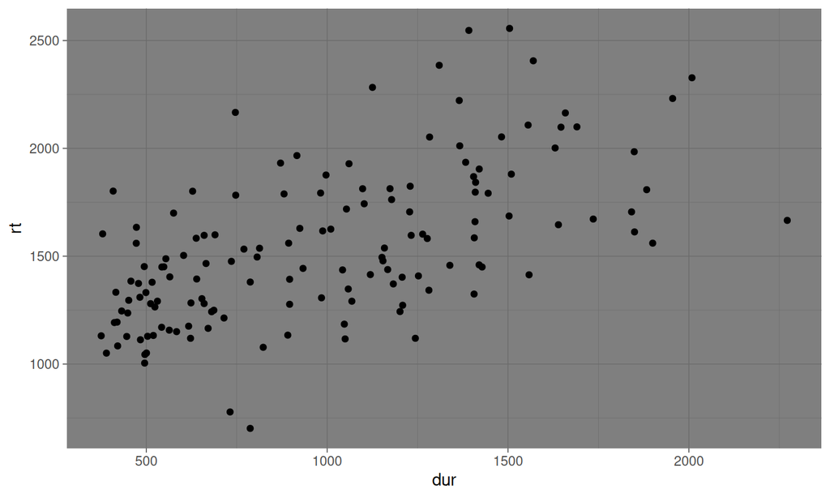

```r
ggplot(d_spellname, aes(x = dur, y = rt)) +
  geom_point() +
  theme_dark()
```

## Adjust One Theme Element

- data
- aesthetics
- geometries
- facets
- statistics
- coordinates
- theme

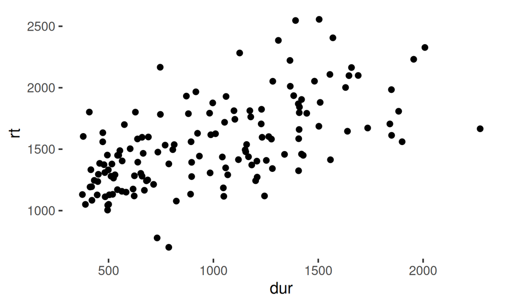

```r
ggplot(d_spellname, aes(x = dur, y = rt)) +
  geom_point() +
  theme(panel.background = element_blank())
```

## Exercise 1: Build A Plot Layer By Layer

Complete RMarkdown document **01_building_ggplot_layers.Rmd**.

This exercise practises reading a plot as a sequence of `ggplot2` layers.

## Read The Code As Layers

What line in the code does what?

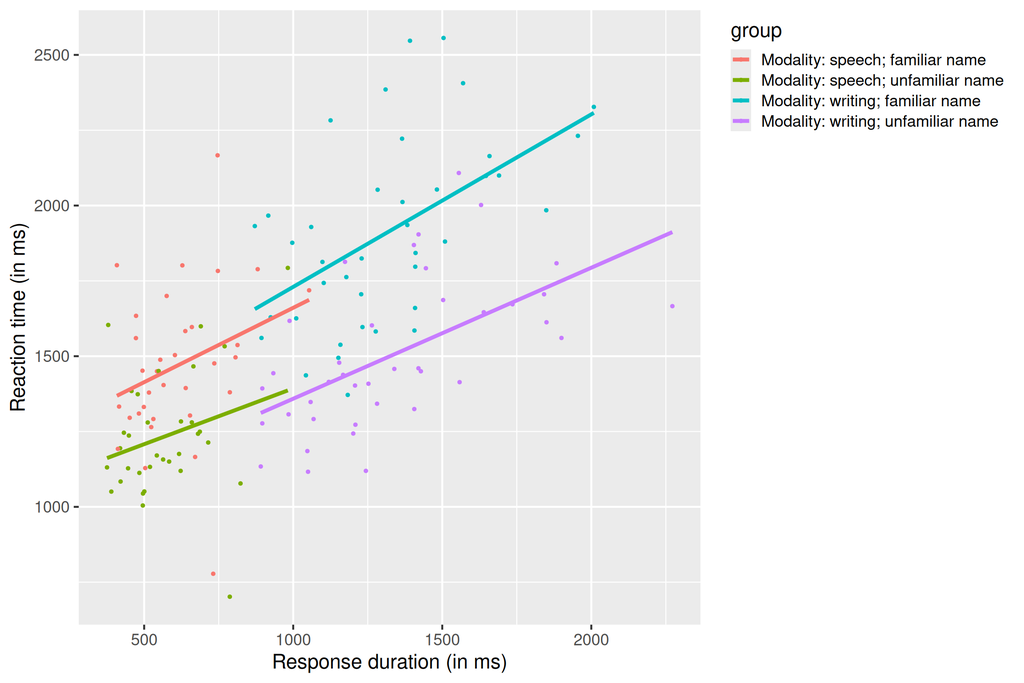

```r
ggplot(data = d_spellname,
       mapping = aes(x = dur,
                     y = rt,
                     colour = group)) +
  geom_point(size = .75) +
  stat_smooth(method = "lm", se = F) +
  labs(x = "Response duration (in ms)",
       y = "Reaction time (in ms)") +
  theme(legend.position = "right",
       legend.justification = "top",
       legend.direction = "vertical")
```

## Mapping Variables And Setting Styles

## Mapping Versus Setting

**Aesthetics**: visual properties mapped to variables (data-driven) e.g. `aes(x = duration, y = time, colour = group)` → colour changes with data and usually creates a scale / legend

**Attributes**: visual properties set manually (constant) e.g. `geom_point(colour = "blue", size = 2)` → colour is fixed and does not describe a variable

*Think*:

Aesthetic = mapping (data → visual)

Attribute = setting (visual → fixed property)

## Attribute: Set One Colour

- appearance of geometries
- e.g. colour, size, shape
- attributes take properties
- aesthetics take variables

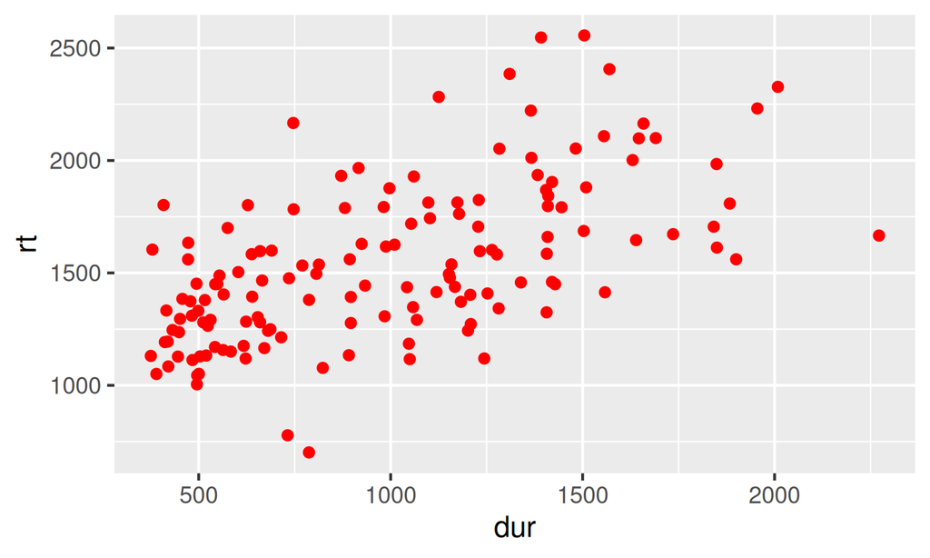

```r
ggplot(d_spellname, aes(x = dur, y = rt)) +
  geom_point(colour = "red")
```

## Aesthetic: Map Colour To A Variable

- appearance of geometries
- e.g. colour, size, shape
- attributes take properties
- aesthetics take variables

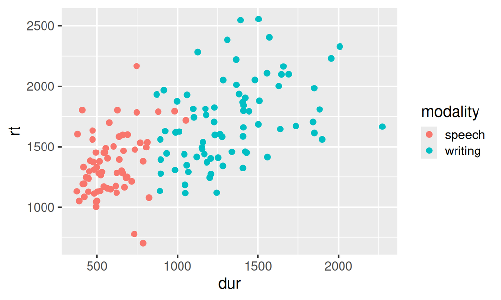

```r
ggplot(d_spellname, aes(x = dur, y = rt)) +
  geom_point(aes(colour = modality))
```

- appearance of geometries
- e.g. colour, size, shape
- attributes take properties
- aesthetics take variables

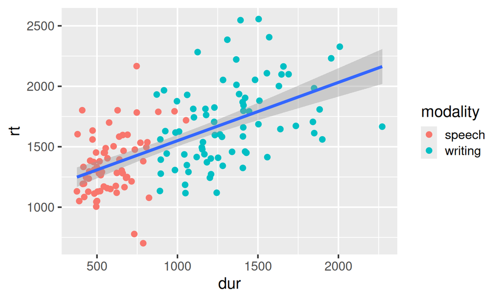

```r
ggplot(d_spellname, aes(x = dur, y = rt)) +
  geom_point(aes(colour = modality)) +
  stat_smooth(method = "lm")
```

## Layer-Specific Mappings

- appearance of geometries
- e.g. colour, size, shape
- attributes take properties
- aesthetics take variables

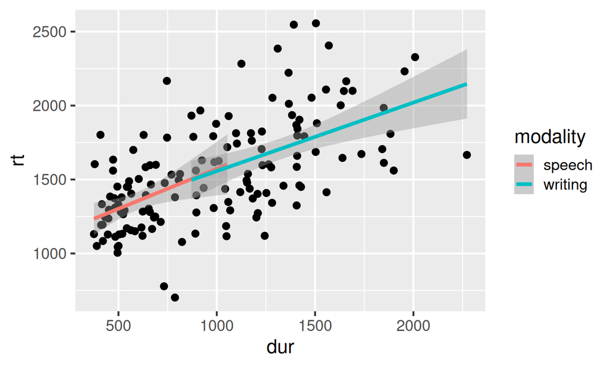

```r
ggplot(d_spellname, aes(x = dur, y = rt)) +
  geom_point() +
  stat_smooth(aes(colour = modality), method = "lm")
```

## Repeating A Mapping Across Layers

- appearance of geometries
- e.g. colour, size, shape
- attributes take properties
- aesthetics take variables

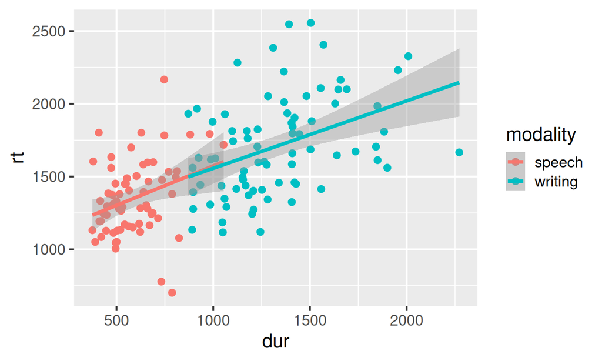

```r
ggplot(d_spellname, aes(x = dur, y = rt)) +
  geom_point(aes(colour = modality)) +
  stat_smooth(aes(colour = modality), method = "lm")
```

## Global Mappings Apply To All Layers

- appearance of geometries
- e.g. colour, size, shape
- attributes take properties
- aesthetics take variables

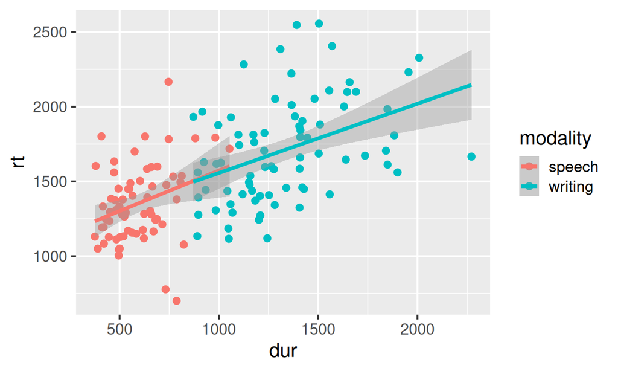

```r
ggplot(d_spellname, aes(x = dur, y = rt, colour = modality)) +
  geom_point() +
  stat_smooth(method = "lm")
```

## Shape Can Encode Groups

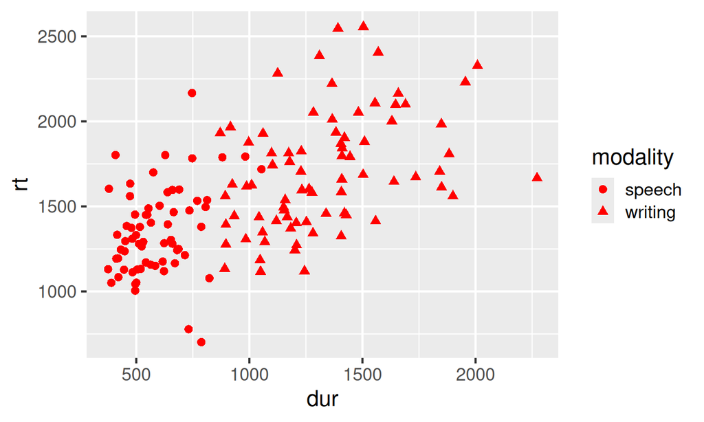

```r
ggplot(d_spellname, aes(x = dur, y = rt, shape = modality)) +
  geom_point(size = 2.5, colour = "red")
```

## Colour Can Encode Groups

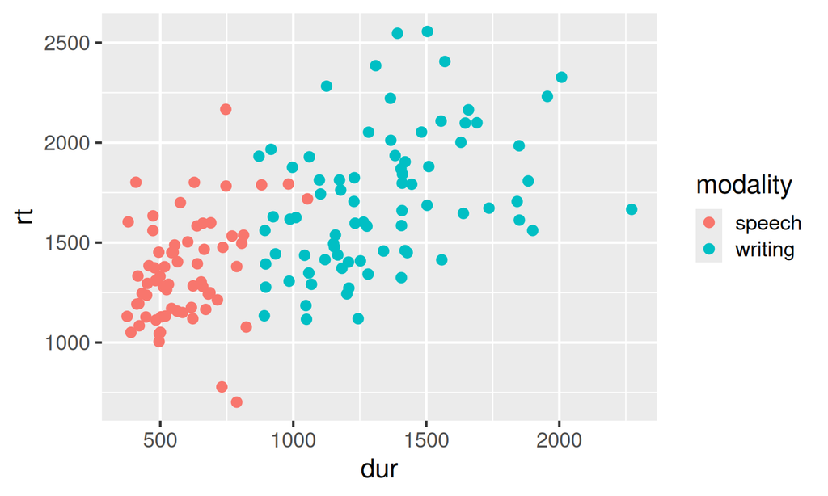

```r
ggplot(d_spellname, aes(x = dur, y = rt, colour = modality)) +
  geom_point(size = 2.5)
```

## Avoid Overloading A Plot

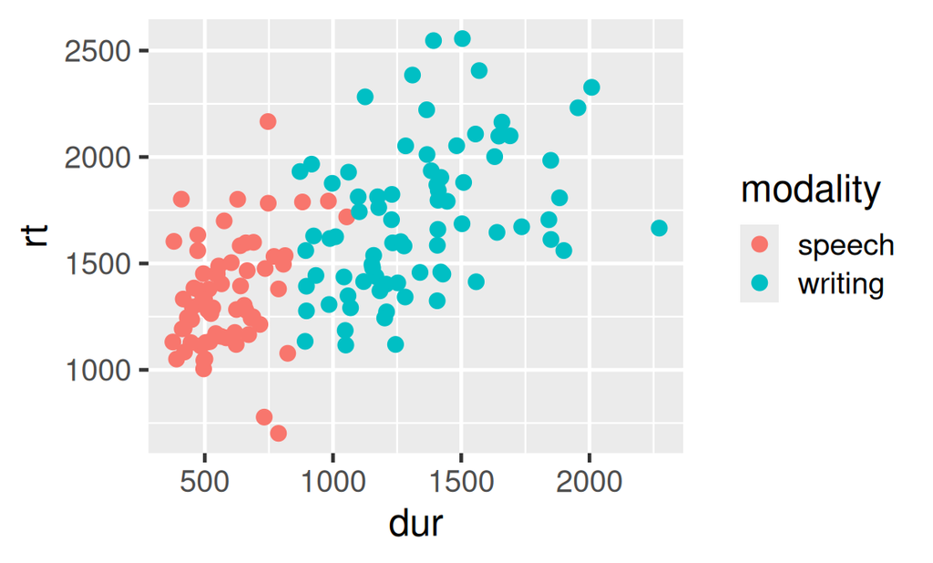

```r
ggplot(d_spellname,
       aes(x = dur, y = rt, colour = modality)) +
  geom_point(size = 2.5)
```

Use one main aesthetic when it answers the question clearly.

- Colour, shape, size, and labels all compete for attention.
- Add another aesthetic only when it improves comparison or accessibility.
- More encodings do not automatically make a plot more informative.

## Use Redundant Coding Carefully

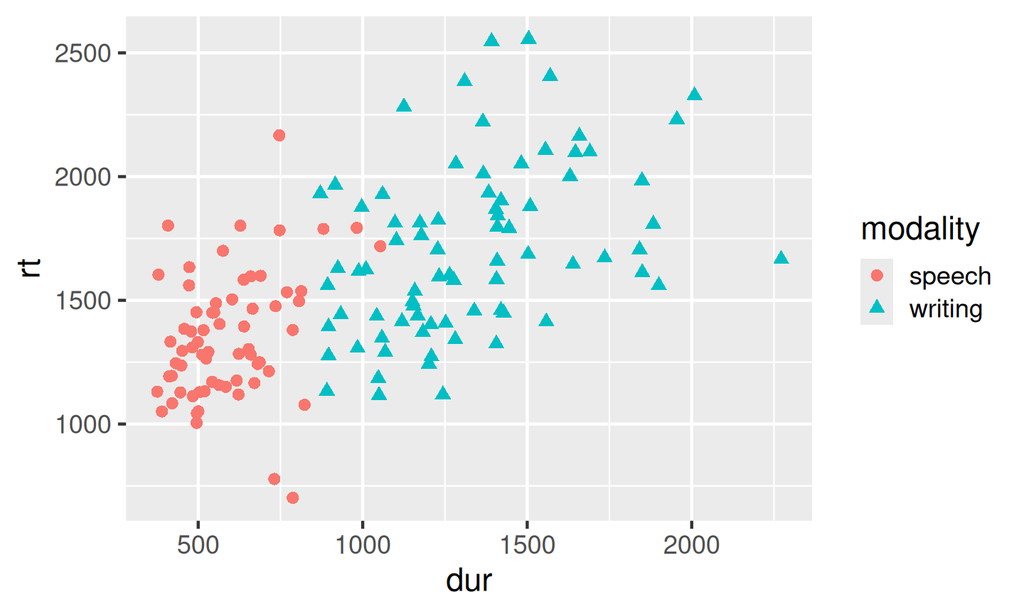

```r
ggplot(d_spellname, aes(x = dur, y = rt,
                        colour = modality,
                        shape = modality)) +
  geom_point(size = 2.5)
```

Sometimes redundant coding is helpful:

- colour helps quick grouping
- shape can help when printed in greyscale
- two groups are still manageable

Avoid this when it creates too many visual groups.

## Common Aesthetics To Recognise

- some are required by geometries; others are optional
- continuous vs discrete variables:
  - e.g. shape and label can only be used for categorical values
- should be chosen to facilitate comprehension
- scatterplot: `geom_point()`

```
x, y, shape, colour, fill, size, alpha, stroke, group
```

- barplot: `geom_bar()`

```
x, y, colour, fill, linewidth, linetype, alpha, width, group
```

- boxplot: `geom_boxplot()`

```
x, y, lower, xlower, upper, xupper, middle, xmiddle, ymin,
xmin, ymax, xmax, weight, colour, fill, size, alpha, shape,
linetype, linewidth, width, group
```

## Exercise 2: Aesthetics And Attributes

Complete RMarkdown document **02_aesthetics_vs_attributes.Rmd**.

This exercise practises deciding whether a visual property should be mapped to a variable or set to a fixed value.

## Variable Type Matters

Before mapping a variable to `colour`, `shape`, `size`, or another aesthetic, ask what kind of variable it is.

| Variable type | Examples | Usually works well with |
| --- | --- | --- |
| Continuous | age, reaction time, vocabulary score | position, gradients, sometimes size |
| Categorical | modality, group, condition | position, colour hue, shape, linetype, facets |

For today, focus on where aesthetics go in the code. We will use variable type more directly next week when choosing plot types.

## Check Your Mappings

If time permits, revisit your plots and ask whether each aesthetic improves the comparison.

Use the two exercise files from today as your main practice for Week 3.

## Recommended Reading

For support with this week’s material, use:

- Andrews (2021), Chapter 4: data visualisation in R. [Online chapter](https://www.mjandrews.org/book/ddsr/assets/chapter_04_visualization.pdf)
- Wickham & Grolemund (2016), Chapter 3: data visualisation with `ggplot2`. [Online chapter](https://r4ds.had.co.nz/data-visualisation.html)

Use the `ggplot2` online book as an optional reference when you want more detail on aesthetics, scales, and facets. [Online book](https://ggplot2-book.org/)

## Homework

Identify a dataset you would like to use for the formative assessment: post a description on our Teams channel.

Think about what you would like to visualise about these data:

- Combination of variables
- Variable types and appropriate aesthetics
- Raw data and / or summary statistics
- Look for appropriate visualisation tools [HERE](https://www.data-to-viz.com/)

## References

Andrews, M. (2021). *Doing data science in R: An introduction for Social Scientists*. SAGE Publications Ltd.

Wickham, H. (2010). A layered grammar of graphics. *Journal of Computational and Graphical Statistics*, *19*(1), 3–28.

Wickham, H. (2016). *ggplot2: Elegant graphics for data analysis*. Springer.

Wickham, H., & Grolemund, G. (2016). *R for data science: Import, tidy, transform, visualize, and model data*. O’Reilly Media, Inc.

Wilkinson, L. (2005). *The grammar of graphics* (2nd ed.). Springer.